# Mean amplitude analyses

David Quiroga

02/07-2020

set relevant libraries:

```r
library(lme4)
library(ggplot2)
library(ez)
library(emmeans)
library(gridExtra)
library(knitr)
```

load and organize data:

```r
#data = read.csv('../../data/MA_grand_window.csv',header = TRUE)
data = read.csv('../../data/MA/MA.csv',header = TRUE, dec = ",")

# rename conditions:
data$condition <- as.character(data$condition)
data[which(data$condition == 'optimal'),'condition'] <- 'LC'
data[which(data$condition == 'alberti'),'condition'] <- 'IC'
data[which(data$condition == 'melody'),'condition'] <- 'HC'

# order factors:
data$condition = factor(data$condition,
                        levels = c('LC','IC','HC',
                                   'familiar','unfamiliar','hihat'))
data$feature = factor(data$feature,
                      levels = c('pitch','intensity','timbre',
                                 'location','rhythm'))
data$group = factor(data$group,
                    levels = c('controls','amusics'))

data$amplitude <- as.numeric(as.character(data$amplitude))
data$latency <- as.numeric(as.character(data$latency))

data$amplitude = data$amplitude/10^-06 # convert to micro Volts

data <- data[!grepl('rhythm',data$feature),] # exclude rhythm
```

Now let’s perform complexity analyses:

First, select data:

```r
cdata <- data[grepl('LC',data$condition) |
             grepl('IC',data$condition) |
             grepl('HC',data$condition),]
```

COMPLEXITY ANALYSES - amplitude

Fit mixed-effects models:

```r
m0 <- lmer(amplitude~1 + (1|subject),data = cdata);#summary(m0)
m1 <- lmer(amplitude~condition + (1|subject), data = cdata);#summary(m1)
m2 <- lmer(amplitude~condition + group + (1|subject), data = cdata);#summary(m2)
m3 <- lmer(amplitude~condition + group + feature + (1|subject),
           data = cdata);#summary(m3)
m4 <- lmer(amplitude~condition + group + feature + condition:feature + (1|subject),
           data = cdata);#summary(m4)
m5 <- lmer(amplitude~condition + group + feature +
             condition:feature + condition:group + (1|subject),
           data = cdata);#summary(m5)
m6 <- lmer(amplitude~condition + group + feature +
             condition:feature + condition:group +
             group:feature + (1|subject),
           data = cdata);#summary(m6)
m7 <- lmer(amplitude~condition + group + feature +
             condition:feature + condition:group +
             group:feature + condition:group:feature + (1|subject),
           data = cdata);#summary(m7)
```

Now perform Likelihood ratio test and store models:

```r
camp.test <- anova(m0,m1,m2,m3,m4,m5,m6,m7);camp.test # Likelihood ratio test
```

```
## Data: cdata
## Models:
## m0: amplitude ~ 1 + (1 | subject)
## m1: amplitude ~ condition + (1 | subject)
## m2: amplitude ~ condition + group + (1 | subject)
## m3: amplitude ~ condition + group + feature + (1 | subject)
## m4: amplitude ~ condition + group + feature + condition:feature +
## m4:     (1 | subject)
## m5: amplitude ~ condition + group + feature + condition:feature +
## m5:     condition:group + (1 | subject)
## m6: amplitude ~ condition + group + feature + condition:feature +
## m6:     condition:group + group:feature + (1 | subject)
## m7: amplitude ~ condition + group + feature + condition:feature +
## m7:     condition:group + group:feature + condition:group:feature +
## m7:     (1 | subject)
##    Df    AIC    BIC  logLik deviance    Chisq Chi Df Pr(>Chisq)
## m0  3 1603.9 1615.9 -798.95   1597.9
## m1  5 1464.9 1485.0 -727.45   1454.9 143.0012      2  < 2.2e-16 ***
## m2  6 1466.1 1490.2 -727.07   1454.1   0.7632      1     0.3823
## m3  9 1419.9 1456.0 -700.97   1401.9  52.1885      3  2.730e-11 ***
## m4 15 1402.4 1462.5 -686.19   1372.4  29.5605      6  4.764e-05 ***
## m5 17 1403.5 1471.7 -684.74   1369.5   2.8969      2     0.2349
## m6 20 1405.8 1486.1 -682.93   1365.8   3.6352      3     0.3036
## m7 26 1414.5 1518.7 -681.23   1362.5   3.3993      6     0.7573
## ---
## Signif. codes:  0 '***' 0.001 '**' 0.01 '*' 0.05 '.' 0.1 ' ' 1
```

```r
camp.models <- list(m0,m1,m2,m3,m4,m5,m6,m7) # store models for report
```

Models 1, 3 and 4 are significant, indicating effects of feature, condition and a feature:condition interaction

Let’s try to reproduce the results with ANOVA:

```r
caov <- ezANOVA(data= cdata, amplitude,subject,within = c(condition,feature),
        between = c(group),detailed = TRUE)
kable(caov$ANOVA)
```

|  | Effect | DFn | DFd | SSn | SSd | F | p | p<.05 | ges |
| --- | --- | --- | --- | --- | --- | --- | --- | --- | --- |
| 1 | (Intercept) | 1 | 32 | 2971.578499 | 387.5127 | 245.3868069 | 0.0000000 | * | 0.7664334 |
| 2 | group | 1 | 32 | 8.796711 | 387.5127 | 0.7264142 | 0.4003820 |  | 0.0096205 |
| 3 | condition | 2 | 64 | 308.303840 | 154.3191 | 63.9306791 | 0.0000000 | * | 0.2539828 |
| 5 | feature | 3 | 96 | 86.217465 | 200.4421 | 13.7643676 | 0.0000002 | * | 0.0869311 |
| 4 | group:condition | 2 | 64 | 4.104770 | 154.3191 | 0.8511758 | 0.4316880 |  | 0.0045123 |
| 6 | group:feature | 3 | 96 | 5.106217 | 200.4421 | 0.8151926 | 0.4885464 |  | 0.0056070 |
| 7 | condition:feature | 6 | 192 | 43.755122 | 163.2992 | 8.5742244 | 0.0000000 | * | 0.0460906 |
| 8 | group:condition:feature | 6 | 192 | 4.730168 | 163.2992 | 0.9269206 | 0.4767226 |  | 0.0051963 |

Results are the same!

Now let’s do some pairwise contrasts:

```r
confint.camp <- as.data.frame(confint(lsmeans(m4,pairwise~condition|feature,
                                              adjust = "Bonferroni")$contrast))
pairwise.camp <-cbind(as.data.frame(lsmeans(m4, pairwise~condition|feature,
                                            adjust="bonferroni")$contrasts),
                      confint.camp[c("lower.CL","upper.CL")])
pairwise.camp <- pairwise.camp[c("feature","contrast","estimate","lower.CL",
                                 "upper.CL","t.ratio","p.value")]
pairwise.camp[,"d"] <- pairwise.camp$estimate/sqrt(VarCorr(m4)$subject[1] + sigma(m4)^2)
pairwise.camp[,3:8] <- round(pairwise.camp[,3:8],2)
colnames(pairwise.camp) <- c("feature","contrast","estimate",
                             "CI 2.5%","CI 97.5%","t","p","d")

kable(pairwise.camp)
```

| feature | contrast | estimate | CI 2.5% | CI 97.5% | t | p | d |
| --- | --- | --- | --- | --- | --- | --- | --- |
| pitch | LC - IC | -0.27 | -0.98 | 0.43 | -0.93 | 1.00 | -0.18 |
| pitch | LC - HC | -1.32 | -2.03 | -0.62 | -4.51 | 0.00 | -0.86 |
| pitch | IC - HC | -1.05 | -1.76 | -0.34 | -3.58 | 0.00 | -0.69 |
| intensity | LC - IC | -2.16 | -2.86 | -1.45 | -7.34 | 0.00 | -1.41 |
| intensity | LC - HC | -2.32 | -3.03 | -1.61 | -7.90 | 0.00 | -1.51 |
| intensity | IC - HC | -0.16 | -0.87 | 0.54 | -0.56 | 1.00 | -0.11 |
| timbre | LC - IC | -1.83 | -2.53 | -1.12 | -6.22 | 0.00 | -1.19 |
| timbre | LC - HC | -2.34 | -3.05 | -1.64 | -7.98 | 0.00 | -1.53 |
| timbre | IC - HC | -0.52 | -1.22 | 0.19 | -1.76 | 0.24 | -0.34 |
| location | LC - IC | -2.17 | -2.87 | -1.46 | -7.38 | 0.00 | -1.41 |
| location | LC - HC | -2.07 | -2.78 | -1.36 | -7.05 | 0.00 | -1.35 |
| location | IC - HC | 0.10 | -0.61 | 0.80 | 0.33 | 1.00 | 0.06 |

```r
write.table(pairwise.camp,file="../results/pairwise_camp.csv",
            sep=",",row.names = FALSE,quote=FALSE) # Export to a table
```

And now a plot:

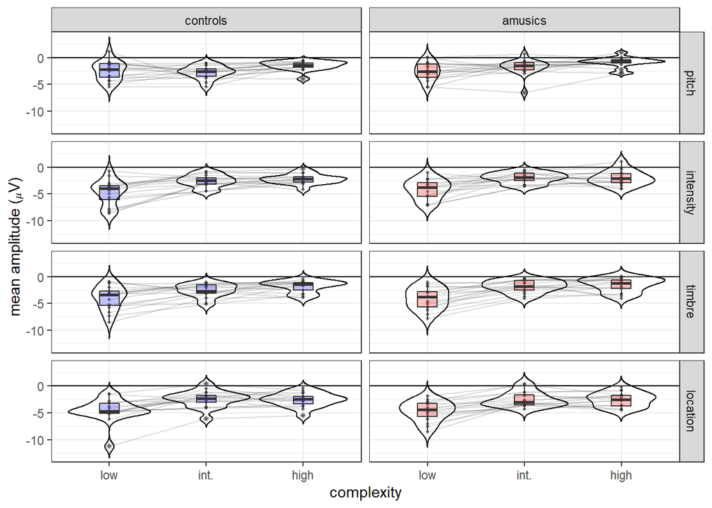

```r
camp <- ggplot(cdata,aes(condition, amplitude)) +
  geom_hline(yintercept = 0) +
  geom_point(alpha = 0.6,color = 'black',size = 0.8) +
  geom_line(aes(group = subject), alpha = 0.15) +
  geom_boxplot(aes(fill = group),alpha = 0.3,
               color = 'black', width = 0.2) +
  geom_violin(aes(color = group),color = 'black',
              alpha = 0.2,trim = FALSE) +
  scale_fill_manual(values = c('blue','red')) +
  facet_grid(feature~group) +
  xlab('complexity') +
  ylab('mean amplitude (\U1D707V)') +
  scale_x_discrete(labels=c("low", "int.","high",
                            "low", "int.","high")) +
  theme_bw() +
  theme(legend.position = "none"); camp
```

COMPLEXITY ANALYSES - Latency

Fit mixed effects models:

```r
latm0 <- lmer(latency~1 + (1|subject),data = cdata);#summary(latm0)
latm1 <- lmer(latency~condition + (1|subject), data = cdata);#summary(latm1)
latm2 <- lmer(latency~condition + group + (1|subject), data = cdata);#summary(latm2)
latm3 <- lmer(latency~condition + group + feature + (1|subject),
              data = cdata);#summary(latm3)
latm4 <- lmer(latency~condition + group + feature + condition:feature + (1|subject),
              data = cdata);#summary(latm4)
latm5 <- lmer(latency~condition + group + feature +
                condition:feature + condition:group + (1|subject),
              data = cdata);#summary(latm5)
latm6 <- lmer(latency~condition + group + feature +
                condition:feature + condition:group +
                group:feature + (1|subject),
              data = cdata);#summary(latm6)
latm7 <- lmer(latency~condition + group + feature +
                condition:feature + condition:group +
                group:feature + condition:group:feature + (1|subject),
                data = cdata) #; summary(latm7)
```

Likelihood ratio test and store models:

```r
clat.test <- anova(latm0,latm1,latm2,latm3,latm4,latm5,latm6,latm7); clat.test
```

```
## Data: cdata
## Models:
## latm0: latency ~ 1 + (1 | subject)
## latm1: latency ~ condition + (1 | subject)
## latm2: latency ~ condition + group + (1 | subject)
## latm3: latency ~ condition + group + feature + (1 | subject)
## latm4: latency ~ condition + group + feature + condition:feature + (1 |
## latm4:     subject)
## latm5: latency ~ condition + group + feature + condition:feature + condition:group +
## latm5:     (1 | subject)
## latm6: latency ~ condition + group + feature + condition:feature + condition:group +
## latm6:     group:feature + (1 | subject)
## latm7: latency ~ condition + group + feature + condition:feature + condition:group +
## latm7:     group:feature + condition:group:feature + (1 | subject)
##       Df    AIC    BIC  logLik deviance    Chisq Chi Df Pr(>Chisq)
## latm0  3 4298.2 4310.2 -2146.1   4292.2
## latm1  5 4269.6 4289.6 -2129.8   4259.6  32.6091      2  8.299e-08 ***
## latm2  6 4270.0 4294.0 -2129.0   4258.0   1.6115      1    0.20429
## latm3  9 4049.3 4085.4 -2015.6   4031.3 226.7054      3  < 2.2e-16 ***
## latm4 15 3988.2 4048.4 -1979.1   3958.2  73.0693      6  9.580e-14 ***
## latm5 17 3991.0 4059.2 -1978.5   3957.0   1.1650      2    0.55850
## latm6 20 3988.4 4068.7 -1974.2   3948.4   8.5935      3    0.03521 *
## latm7 26 3998.9 4103.2 -1973.5   3946.9   1.5134      6    0.95860
## ---
## Signif. codes:  0 '***' 0.001 '**' 0.01 '*' 0.05 '.' 0.1 ' ' 1
```

```r
clat.models <- list(latm0,latm1,latm2,latm3,latm4,latm5,latm6,latm7)
```

Now let’s confirm this with an ANOVA:

```r
claov <- ezANOVA(data = cdata, latency,subject,within = c(condition,feature),
         between = c(group),detailed = TRUE)
kable(claov$ANOVA)
```

|  | Effect | DFn | DFd | SSn | SSd | F | p | p<.05 | ges |
| --- | --- | --- | --- | --- | --- | --- | --- | --- | --- |
| 1 | (Intercept) | 1 | 32 | 8110320.039 | 84815.25 | 3059.9476657 | 0.0000000 | * | 0.9526563 |
| 2 | group | 1 | 32 | 4116.706 | 84815.25 | 1.5531945 | 0.2217112 |  | 0.0101105 |
| 3 | condition | 2 | 64 | 66601.593 | 74396.86 | 28.6470545 | 0.0000000 | * | 0.1418092 |
| 5 | feature | 3 | 96 | 332306.020 | 98029.76 | 108.4751418 | 0.0000000 | * | 0.4518952 |
| 4 | group:condition | 2 | 64 | 1020.044 | 74396.86 | 0.4387472 | 0.6467687 |  | 0.0025244 |
| 6 | group:feature | 3 | 96 | 7426.882 | 98029.76 | 2.4243681 | 0.0704179 |  | 0.0180931 |
| 7 | condition:feature | 6 | 192 | 70765.525 | 145812.94 | 15.5301496 | 0.0000000 | * | 0.1493510 |
| 8 | group:condition:feature | 6 | 192 | 1290.368 | 145812.94 | 0.2831831 | 0.9444110 |  | 0.0031913 |

The results are the same, but note that the interaction group:feature is not detected anymore. There was a trend, though.

Now let’s do pairwise comparisons:

```r
confint.clat <- as.data.frame(confint(lsmeans(latm4,pairwise~condition|feature,
                                              adjust = "Bonferroni")$contrast))
pairwise.clat <-cbind(as.data.frame(lsmeans(latm4, pairwise~condition|feature,
                                            adjust="bonferroni")$contrasts),
                      confint.clat[c("lower.CL","upper.CL")])
pairwise.clat <- pairwise.clat[c("feature","contrast","estimate","lower.CL",
                                 "upper.CL","t.ratio","p.value")]
pairwise.clat[," d"] <- pairwise.clat$estimate/sqrt(VarCorr(latm4)$subject[1] + sigma(latm4)^2)
pairwise.clat[,3:8] <- round(pairwise.clat[,3:8],2)
colnames(pairwise.clat) <- c("feature","contrast","estimate",
                             "CI 2.5%","CI 97.5%","t","p","d")
kable(pairwise.clat)
```

| feature | contrast | estimate | CI 2.5% | CI 97.5% | t | p | d |
| --- | --- | --- | --- | --- | --- | --- | --- |
| pitch | LC - IC | -62.15 | -79.68 | -44.61 | -8.52 | 0.00 | -1.92 |
| pitch | LC - HC | -78.38 | -95.92 | -60.85 | -10.75 | 0.00 | -2.42 |
| pitch | IC - HC | -16.24 | -33.77 | 1.30 | -2.23 | 0.08 | -0.50 |
| intensity | LC - IC | -24.41 | -41.95 | -6.88 | -3.35 | 0.00 | -0.75 |
| intensity | LC - HC | -13.15 | -30.68 | 4.39 | -1.80 | 0.22 | -0.41 |
| intensity | IC - HC | 11.26 | -6.27 | 28.80 | 1.55 | 0.37 | 0.35 |
| timbre | LC - IC | -24.76 | -42.30 | -7.23 | -3.40 | 0.00 | -0.76 |
| timbre | LC - HC | -16.38 | -33.92 | 1.15 | -2.25 | 0.08 | -0.51 |
| timbre | IC - HC | 8.38 | -9.15 | 25.92 | 1.15 | 0.75 | 0.26 |
| location | LC - IC | 1.47 | -16.06 | 19.00 | 0.20 | 1.00 | 0.05 |
| location | LC - HC | 1.00 | -16.53 | 18.53 | 0.14 | 1.00 | 0.03 |
| location | IC - HC | -0.47 | -18.00 | 17.06 | -0.06 | 1.00 | -0.01 |

```r
write.table(pairwise.clat,file="../results/pairwise_clat1.csv",
            sep=",",row.names = FALSE,quote=FALSE) # Export to a table
```

Now pairwise contrasts: group:feature

```r
confint.clat2 <- as.data.frame(confint(lsmeans(latm6,pairwise~group|feature,
                                              adjust = "Bonferroni")$contrast))
pairwise.clat2 <-cbind(as.data.frame(lsmeans(latm6, pairwise~group|feature,
                                            adjust="bonferroni")$contrasts),
                      confint.clat2[c("lower.CL","upper.CL")])
pairwise.clat2 <- pairwise.clat2[c("feature","contrast","estimate","lower.CL",
                                 "upper.CL","t.ratio","p.value")]
pairwise.clat2[,"d"] <- pairwise.clat2$estimate/sqrt(VarCorr(latm6)$subject[1] + sigma(latm6)^2)
pairwise.clat2[,3:8] <- round(pairwise.clat2[,3:8],2)
colnames(pairwise.clat2) <- c("feature","contrast","estimate",
                             "CI 2.5%","CI 97.5%","t","p","d")
kable(pairwise.clat2)
```

| feature | contrast | estimate | CI 2.5% | CI 97.5% | t | p | d |
| --- | --- | --- | --- | --- | --- | --- | --- |
| pitch | controls - amusics | -20.98 | -35.29 | -6.67 | -2.90 | 0.00 | -0.65 |
| intensity | controls - amusics | 0.29 | -14.02 | 14.61 | 0.04 | 0.97 | 0.01 |
| timbre | controls - amusics | -3.16 | -17.47 | 11.15 | -0.44 | 0.66 | -0.10 |
| location | controls - amusics | -1.57 | -15.88 | 12.74 | -0.22 | 0.83 | -0.05 |

```r
write.table(pairwise.clat2,file="../results/pairwise_clat2.csv",
            sep=",",row.names = FALSE,quote=FALSE)
```

Here it can be seen that amusics had longer MMN latencies than controls for pitch (20 ms difference)

Now a plot:

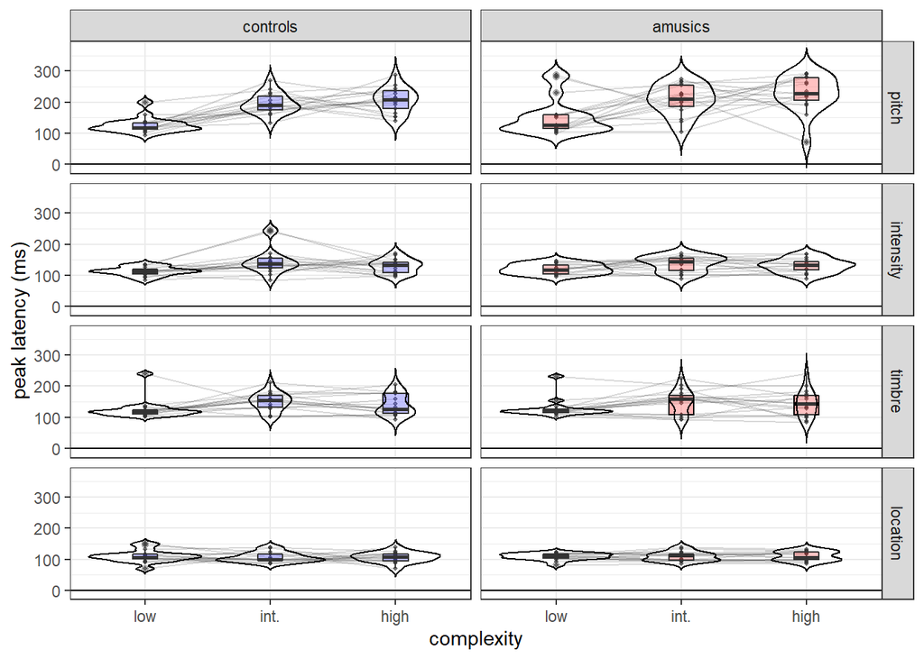

```r
clat <- ggplot(cdata,aes(condition, latency)) +
  geom_hline(yintercept = 0) +
  geom_point(alpha = 0.6,color = 'black',size = 0.8) +
  geom_line(aes(group = subject), alpha = 0.15) +
  geom_boxplot(aes(fill = group),alpha = 0.3,
               color = 'black', width = 0.2) +
  geom_violin(aes(color = group),color = 'black',
              alpha = 0.2,trim = FALSE) +
  scale_fill_manual(values = c('blue','red')) +
  facet_grid(feature~group) +
  xlab('complexity') +
  ylab('peak latency (ms)') +
  scale_x_discrete(labels=c("low", "int.","high",
                            "low", "int.","high")) +
  theme_bw() +
  theme(legend.position = "none");clat
```

Now let’s make a joint report for complexity effects regarding latency and amplitude:

```r
complexity.report <- data.frame('model' = rownames(camp.test))
complexity.report[2:nrow(complexity.report),'null'] <- complexity.report[1:nrow(complexity.report)-1,'model']

complexity.report <- cbind(complexity.report,round(camp.test[,c('AIC','Chisq','Pr(>Chisq)')],2),
                                 round(clat.test[,c('AIC','Chisq','Pr(>Chisq)')],2))
colnames(complexity.report) <- c('model','null','AIC','X2','p','AIC','X2','p')

write.table(complexity.report,file="../results/complexity.report.csv",
            sep= ",",row.names = FALSE,quote=FALSE)
kable(complexity.report)
```

|  | model | null | AIC | X2 | p | AIC | X2 | p |
| --- | --- | --- | --- | --- | --- | --- | --- | --- |
| m0 | m0 | NA | 1603.90 | NA | NA | 4298.18 | NA | NA |
| m1 | m1 | m0 | 1464.90 | 143.00 | 0.00 | 4269.57 | 32.61 | 0.00 |
| m2 | m2 | m1 | 1466.13 | 0.76 | 0.38 | 4269.96 | 1.61 | 0.20 |
| m3 | m3 | m2 | 1419.94 | 52.19 | 0.00 | 4049.26 | 226.71 | 0.00 |
| m4 | m4 | m3 | 1402.38 | 29.56 | 0.00 | 3988.19 | 73.07 | 0.00 |
| m5 | m5 | m4 | 1403.49 | 2.90 | 0.23 | 3991.02 | 1.16 | 0.56 |
| m6 | m6 | m5 | 1405.85 | 3.64 | 0.30 | 3988.43 | 8.59 | 0.04 |
| m7 | m7 | m6 | 1414.45 | 3.40 | 0.76 | 3998.92 | 1.51 | 0.96 |

And a similar pairwise table:

```r
complexity.pw <- cbind(pairwise.camp,pairwise.clat[,c(3:ncol(pairwise.clat))])
write.table(complexity.pw,file="../results/pairwise_complexity.csv",
            sep=",",row.names = FALSE,quote=FALSE)
kable(complexity.pw)
```

| feature | contrast | estimate | CI 2.5% | CI 97.5% | t | p | d | estimate | CI 2.5% | CI 97.5% | t | p | d |
| --- | --- | --- | --- | --- | --- | --- | --- | --- | --- | --- | --- | --- | --- |
| pitch | LC - IC | -0.27 | -0.98 | 0.43 | -0.93 | 1.00 | -0.18 | -62.15 | -79.68 | -44.61 | -8.52 | 0.00 | -1.92 |
| pitch | LC - HC | -1.32 | -2.03 | -0.62 | -4.51 | 0.00 | -0.86 | -78.38 | -95.92 | -60.85 | -10.75 | 0.00 | -2.42 |
| pitch | IC - HC | -1.05 | -1.76 | -0.34 | -3.58 | 0.00 | -0.69 | -16.24 | -33.77 | 1.30 | -2.23 | 0.08 | -0.50 |
| intensity | LC - IC | -2.16 | -2.86 | -1.45 | -7.34 | 0.00 | -1.41 | -24.41 | -41.95 | -6.88 | -3.35 | 0.00 | -0.75 |
| intensity | LC - HC | -2.32 | -3.03 | -1.61 | -7.90 | 0.00 | -1.51 | -13.15 | -30.68 | 4.39 | -1.80 | 0.22 | -0.41 |
| intensity | IC - HC | -0.16 | -0.87 | 0.54 | -0.56 | 1.00 | -0.11 | 11.26 | -6.27 | 28.80 | 1.55 | 0.37 | 0.35 |
| timbre | LC - IC | -1.83 | -2.53 | -1.12 | -6.22 | 0.00 | -1.19 | -24.76 | -42.30 | -7.23 | -3.40 | 0.00 | -0.76 |
| timbre | LC - HC | -2.34 | -3.05 | -1.64 | -7.98 | 0.00 | -1.53 | -16.38 | -33.92 | 1.15 | -2.25 | 0.08 | -0.51 |
| timbre | IC - HC | -0.52 | -1.22 | 0.19 | -1.76 | 0.24 | -0.34 | 8.38 | -9.15 | 25.92 | 1.15 | 0.75 | 0.26 |
| location | LC - IC | -2.17 | -2.87 | -1.46 | -7.38 | 0.00 | -1.41 | 1.47 | -16.06 | 19.00 | 0.20 | 1.00 | 0.05 |
| location | LC - HC | -2.07 | -2.78 | -1.36 | -7.05 | 0.00 | -1.35 | 1.00 | -16.53 | 18.53 | 0.14 | 1.00 | 0.03 |
| location | IC - HC | 0.10 | -0.61 | 0.80 | 0.33 | 1.00 | 0.06 | -0.47 | -18.00 | 17.06 | -0.06 | 1.00 | -0.01 |

And let’s put the complexity plots together:

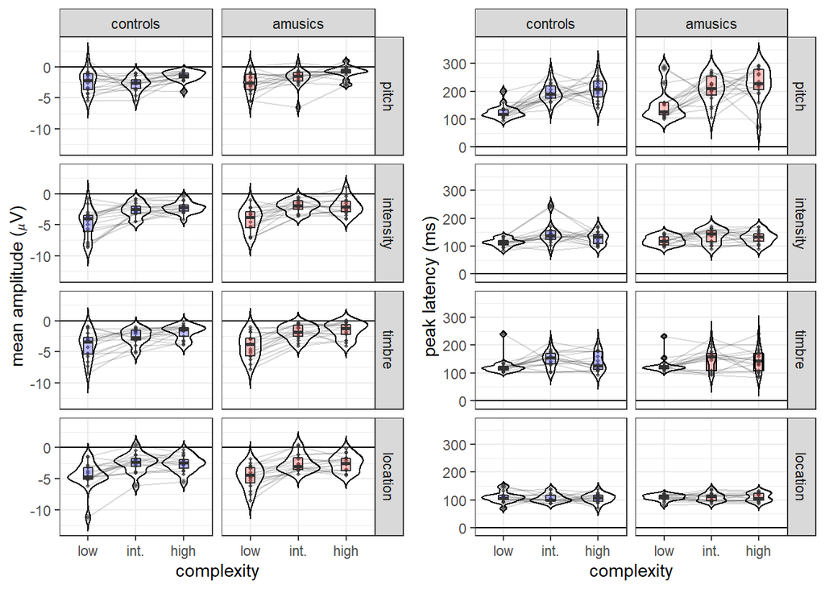

```r
cplots <- arrangeGrob(camp,clat,ncol=2);plot(cplots)
```

```r
ggsave("../results/MA_complexity.pdf", plot=cplots,width = 170, height = 150, units = 'mm', dpi = 300)
ggsave("../results/MA_complexity.png", plot=cplots,width = 170, height = 150, units = 'mm', dpi = 300)
```

Now let’s move on to familiarity analyses - first, select data:

```r
fdata = data[grepl('familiar',data$condition) |
             grepl('unfamiliar',data$condition),]
```

FAMILIARITY ANALYSES - Amplitudes

fit mixed-effects models:

```r
fm0 <- lmer(amplitude~1 + (1|subject),data = fdata)#;summary(fm0)
fm1 <- lmer(amplitude~condition + (1|subject), data = fdata)#;summary(fm1)
fm2 <- lmer(amplitude~condition + group + (1|subject), data = fdata)#;summary(fm2)
fm3 <- lmer(amplitude~condition + group + feature + (1|subject),
           data = fdata)#;summary(fm3)
fm4 <- lmer(amplitude~condition + group + feature + condition:feature + (1|subject),
           data = fdata)#;summary(fm4)
fm5 <- lmer(amplitude~condition + group + feature +
             condition:feature + condition:group + (1|subject),
           data = fdata)#;summary(fm5)
fm6 <- lmer(amplitude~condition + group + feature +
             condition:feature + condition:group +
             group:feature + (1|subject),
           data = fdata)#;summary(fm6)
fm7 <- lmer(amplitude~condition + group + feature +
             condition:feature + condition:group +
             group:feature + condition:group:feature + (1|subject),
           data = fdata)#;summary(fm7)
```

Likelihood ratio test and store models:

```r
famp.test <- anova(fm0,fm1,fm2,fm3,fm4,fm5,fm6,fm7); famp.test
```

```
## Data: fdata
## Models:
## fm0: amplitude ~ 1 + (1 | subject)
## fm1: amplitude ~ condition + (1 | subject)
## fm2: amplitude ~ condition + group + (1 | subject)
## fm3: amplitude ~ condition + group + feature + (1 | subject)
## fm4: amplitude ~ condition + group + feature + condition:feature +
## fm4:     (1 | subject)
## fm5: amplitude ~ condition + group + feature + condition:feature +
## fm5:     condition:group + (1 | subject)
## fm6: amplitude ~ condition + group + feature + condition:feature +
## fm6:     condition:group + group:feature + (1 | subject)
## fm7: amplitude ~ condition + group + feature + condition:feature +
## fm7:     condition:group + group:feature + condition:group:feature +
## fm7:     (1 | subject)
##     Df    AIC    BIC  logLik deviance   Chisq Chi Df Pr(>Chisq)
## fm0  3 874.99 885.63 -434.50   868.99
## fm1  4 874.28 888.46 -433.14   866.28  2.7094      1    0.09976 .
## fm2  5 875.41 893.13 -432.70   865.41  0.8780      1    0.34874
## fm3  8 806.63 834.99 -395.31   790.63 74.7757      3  4.048e-16 ***
## fm4 11 805.45 844.45 -391.73   783.45  7.1758      3    0.06650 .
## fm5 12 806.99 849.53 -391.50   782.99  0.4623      1    0.49654
## fm6 15 808.77 861.94 -389.38   778.77  4.2263      3    0.23804
## fm7 18 811.28 875.09 -387.64   775.28  3.4874      3    0.32240
## ---
## Signif. codes:  0 '***' 0.001 '**' 0.01 '*' 0.05 '.' 0.1 ' ' 1
```

```r
famp.models <- list(fm0,fm1,fm2,fm3,fm4,fm5,fm6,fm7)
```

The results clearly show an effect of feature but nothing else

Let’s confirm with ANOVA:

```r
faov <- ezANOVA(data= fdata, amplitude,subject,within = c(condition,feature),
        between = c(group),detailed = TRUE)
kable(faov$ANOVA)
```

|  | Effect | DFn | DFd | SSn | SSd | F | p | p<.05 | ges |
| --- | --- | --- | --- | --- | --- | --- | --- | --- | --- |
| 1 | (Intercept) | 1 | 30 | 1231.1911317 | 273.85683 | 134.8724242 | 0.0000000 | * | 0.7199992 |
| 2 | group | 1 | 30 | 7.6182296 | 273.85683 | 0.8345488 | 0.3682444 |  | 0.0156619 |
| 3 | condition | 1 | 30 | 3.7292199 | 32.36632 | 3.4565746 | 0.0728344 |  | 0.0077285 |
| 5 | feature | 3 | 90 | 86.9779853 | 124.14190 | 21.0190076 | 0.0000000 | * | 0.1537321 |
| 4 | group:condition | 1 | 30 | 0.4382549 | 32.36632 | 0.4062138 | 0.5287320 |  | 0.0009145 |
| 6 | group:feature | 3 | 90 | 3.9646648 | 124.14190 | 0.9580967 | 0.4161534 |  | 0.0082124 |
| 7 | condition:feature | 3 | 90 | 6.9195410 | 48.43344 | 4.2860102 | 0.0070998 | * | 0.0142460 |
| 8 | group:condition:feature | 3 | 90 | 3.2156338 | 48.43344 | 1.9917852 | 0.1208516 |  | 0.0066712 |

The anova suggested also a feature by condition interaction, which was only a trend in the LR test. Otherwise, results are identical

Let’s do some pairwise contrasts:

```r
confint.famp <- as.data.frame(confint(lsmeans(fm4,pairwise~feature,
                                              adjust = "Bonferroni")$contrast))
pairwise.famp <-cbind(as.data.frame(lsmeans(fm4, pairwise~feature,
                                            adjust="bonferroni")$contrasts),
                      confint.famp[c("lower.CL","upper.CL")])
pairwise.famp <- pairwise.famp[c("contrast","estimate","lower.CL",
                                 "upper.CL","t.ratio","p.value")]
pairwise.famp[,"d"] <- pairwise.famp$estimate/sqrt(VarCorr(fm4)$subject[1] + sigma(fm4)^2)
pairwise.famp[,2:7] <- round(pairwise.famp[,2:7],2)
colnames(pairwise.famp) <- c("contrast","estimate",
                             "CI 2.5%","CI 97.5%","t","p","d")
kable(pairwise.famp)
```

| contrast | estimate | CI 2.5% | CI 97.5% | t | p | d |
| --- | --- | --- | --- | --- | --- | --- |
| pitch - intensity | 0.86 | 0.39 | 1.32 | 4.91 | 0 | 0.61 |
| pitch - timbre | 0.63 | 0.17 | 1.10 | 3.61 | 0 | 0.45 |
| pitch - location | 1.63 | 1.16 | 2.10 | 9.32 | 0 | 1.15 |
| intensity - timbre | -0.23 | -0.69 | 0.24 | -1.30 | 1 | -0.16 |
| intensity - location | 0.77 | 0.31 | 1.24 | 4.41 | 0 | 0.55 |
| timbre - location | 1.00 | 0.53 | 1.46 | 5.70 | 0 | 0.71 |

```r
write.table(pairwise.famp,file="../results/pairwise_famp1.csv",
            sep=",",row.names = FALSE,quote=FALSE) # Export to a table
```

And now taking into account the conditions:

```r
confint.famp2 <- as.data.frame(confint(lsmeans(fm4,pairwise~condition|feature,
                                              adjust = "Bonferroni")$contrast))
pairwise.famp2 <-cbind(as.data.frame(lsmeans(fm4, pairwise~condition|feature,
                                            adjust="bonferroni")$contrasts),
                      confint.famp2[c("lower.CL","upper.CL")])
pairwise.famp2 <- pairwise.famp2[c("contrast","feature","estimate","lower.CL",
                                 "upper.CL","t.ratio","p.value")]
pairwise.famp2[,"d"] <- pairwise.famp2$estimate/sqrt(VarCorr(fm4)$subject[1] + sigma(fm4)^2)
pairwise.famp2[,3:8] <- round(pairwise.famp2[,3:8],2)
colnames(pairwise.famp2) <- c("contrast","feature","estimate",
                             "CI 2.5%","CI 97.5%","t","p","d")
kable(pairwise.famp2)
```

| contrast | feature | estimate | CI 2.5% | CI 97.5% | t | p | d |
| --- | --- | --- | --- | --- | --- | --- | --- |
| familiar - unfamiliar | pitch | -0.30 | -0.79 | 0.19 | -1.20 | 0.23 | -0.21 |
| familiar - unfamiliar | intensity | -0.75 | -1.24 | -0.26 | -3.03 | 0.00 | -0.53 |
| familiar - unfamiliar | timbre | 0.11 | -0.38 | 0.60 | 0.45 | 0.65 | 0.08 |
| familiar - unfamiliar | location | -0.03 | -0.52 | 0.46 | -0.12 | 0.90 | -0.02 |

```r
write.table(pairwise.famp2,file="../results/pairwise_famp2.csv",
            sep=",",row.names = FALSE,quote=FALSE)
```

This confirms the differences for intensity

And now taking into account the conditions per group:

```r
confint.famp3 <- as.data.frame(confint(lsmeans(fm7,pairwise~condition|group|feature,
                                              adjust = "Bonferroni")$contrast))
pairwise.famp3 <-cbind(as.data.frame(lsmeans(fm7, pairwise~condition|group|feature,
                                            adjust="bonferroni")$contrasts),
                      confint.famp3[c("lower.CL","upper.CL")])
pairwise.famp3 <- pairwise.famp3[c("contrast","feature","group","estimate","lower.CL",
                                 "upper.CL","t.ratio","p.value")]
pairwise.famp3[,"d"] <- pairwise.famp3$estimate/sqrt(VarCorr(fm7)$subject[1] + sigma(fm7)^2)
pairwise.famp3[,4:9] <- round(pairwise.famp3[,4:9],2)
colnames(pairwise.famp3) <- c("contrast","feature","group","estimate",
                             "CI 2.5%","CI 97.5%","t","p","d")
kable(pairwise.famp3)
```

| contrast | feature | group | estimate | CI 2.5% | CI 97.5% | t | p | d |
| --- | --- | --- | --- | --- | --- | --- | --- | --- |
| familiar - unfamiliar | pitch | controls | 0.12 | -0.57 | 0.81 | 0.34 | 0.74 | 0.08 |
| familiar - unfamiliar | pitch | amusics | -0.71 | -1.40 | -0.02 | -2.04 | 0.04 | -0.50 |
| familiar - unfamiliar | intensity | controls | -0.96 | -1.65 | -0.27 | -2.76 | 0.01 | -0.68 |
| familiar - unfamiliar | intensity | amusics | -0.54 | -1.23 | 0.15 | -1.54 | 0.12 | -0.38 |
| familiar - unfamiliar | timbre | controls | 0.14 | -0.55 | 0.83 | 0.39 | 0.69 | 0.10 |
| familiar - unfamiliar | timbre | amusics | 0.09 | -0.60 | 0.78 | 0.25 | 0.80 | 0.06 |
| familiar - unfamiliar | location | controls | 0.07 | -0.62 | 0.76 | 0.21 | 0.84 | 0.05 |
| familiar - unfamiliar | location | amusics | -0.13 | -0.82 | 0.56 | -0.38 | 0.71 | -0.09 |

```r
write.table(pairwise.famp3,file="../results/pairwise_famp3.csv",
            sep=",",row.names = FALSE,quote=FALSE)
ref <- VarCorr(fm7)
```

Now let’s make a figure:

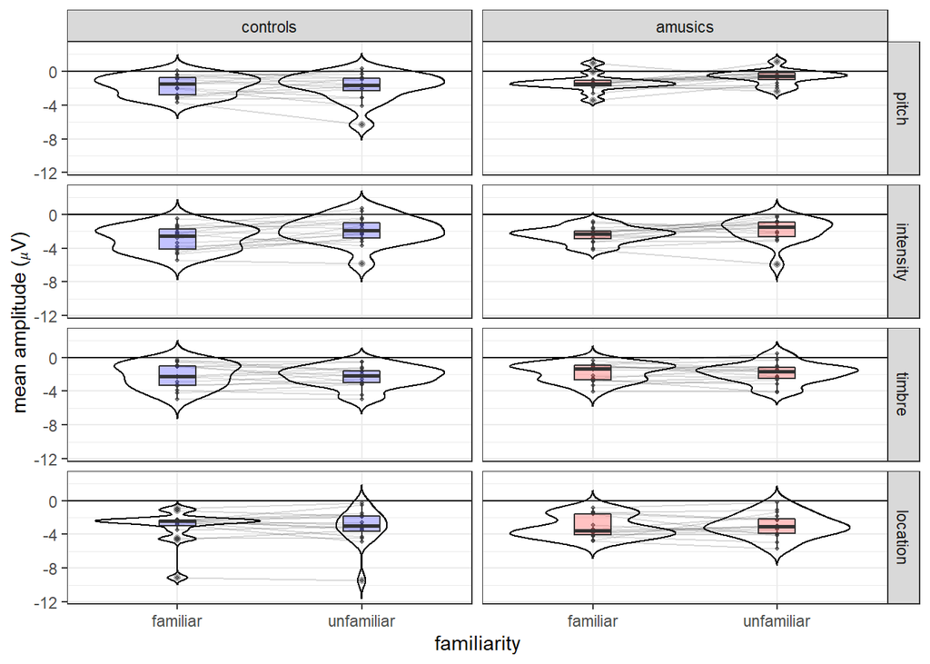

```r
famp <- ggplot(fdata,aes(condition, amplitude)) +
  geom_hline(yintercept = 0) +
  geom_point(alpha = 0.6,color = 'black',size = 0.8) +
  geom_line(aes(group = subject), alpha = 0.15) +
  geom_boxplot(aes(fill = group),alpha = 0.3,
               color = 'black', width = 0.2) +
  geom_violin(aes(color = group),color = 'black',
              alpha = 0.2,trim = FALSE) +
  scale_fill_manual(values = c('blue','red')) +
  facet_grid(feature~group) +
  xlab('familiarity') +
  ylab('mean amplitude (\U1D707V)') +
  theme_bw() +
  theme(legend.position = "none"); famp
```

FAMILIARITY ANALYSES - latencies

fitting mixed-effects models:

```r
flatm0 <- lmer(latency~1 + (1|subject),data = fdata)#;summary(flatm0)
flatm1 <- lmer(latency~condition + (1|subject), data = fdata)#;summary(flatm1)
flatm2 <- lmer(latency~condition + group + (1|subject), data = fdata)#;summary(flatm2)
flatm3 <- lmer(latency~condition + group + feature + (1|subject),
           data = fdata)#;summary(flatm3)
flatm4 <- lmer(latency~condition + group + feature + condition:feature + (1|subject),
           data = fdata)#;summary(flatm4)
flatm5 <- lmer(latency~condition + group + feature +
             condition:feature + condition:group + (1|subject),
           data = fdata)#;summary(flatm5)
flatm6 <- lmer(latency~condition + group + feature +
             condition:feature + condition:group +
             group:feature + (1|subject),
           data = fdata)#;summary(flatm6)
flatm7 <- lmer(latency~condition + group + feature +
             condition:feature + condition:group +
             group:feature + condition:group:feature + (1|subject),
           data = fdata)#;summary(flatm7)
```

Likelihood ratio test and store models:

```r
flat.test <- anova(flatm0,flatm1,flatm2,flatm3,flatm4,flatm5,flatm6,flatm7); flat.test
```

```
## Data: fdata
## Models:
## flatm0: latency ~ 1 + (1 | subject)
## flatm1: latency ~ condition + (1 | subject)
## flatm2: latency ~ condition + group + (1 | subject)
## flatm3: latency ~ condition + group + feature + (1 | subject)
## flatm4: latency ~ condition + group + feature + condition:feature + (1 |
## flatm4:     subject)
## flatm5: latency ~ condition + group + feature + condition:feature + condition:group +
## flatm5:     (1 | subject)
## flatm6: latency ~ condition + group + feature + condition:feature + condition:group +
## flatm6:     group:feature + (1 | subject)
## flatm7: latency ~ condition + group + feature + condition:feature + condition:group +
## flatm7:     group:feature + condition:group:feature + (1 | subject)
##        Df    AIC    BIC  logLik deviance    Chisq Chi Df Pr(>Chisq)
## flatm0  3 2748.6 2759.3 -1371.3   2742.6
## flatm1  4 2750.1 2764.3 -1371.1   2742.1   0.5101      1     0.4751
## flatm2  5 2752.0 2769.7 -1371.0   2742.0   0.1523      1     0.6963
## flatm3  8 2597.7 2626.0 -1290.8   2581.7 160.2998      3     <2e-16 ***
## flatm4 11 2603.4 2642.4 -1290.7   2581.4   0.2499      3     0.9692
## flatm5 12 2604.3 2646.9 -1290.2   2580.3   1.0778      1     0.2992
## flatm6 15 2609.3 2662.5 -1289.7   2579.3   1.0301      3     0.7940
## flatm7 18 2614.0 2677.8 -1289.0   2578.0   1.3405      3     0.7195
## ---
## Signif. codes:  0 '***' 0.001 '**' 0.01 '*' 0.05 '.' 0.1 ' ' 1
```

```r
flat.models <- list(flatm0,flatm1,flatm2,flatm3,flatm4,flatm5,flatm6,flatm7)
```

an effect of feature but nothing else

Let’s confirm with an ANOVA:

```r
flaov <- ezANOVA(data= fdata, latency,subject,within = c(condition,feature),
         between = c(group),detailed = TRUE)
kable(flaov$ANOVA)
```

|  | Effect | DFn | DFd | SSn | SSd | F | p | p<.05 | ges |
| --- | --- | --- | --- | --- | --- | --- | --- | --- | --- |
| 1 | (Intercept) | 1 | 30 | 5717478.7656 | 80228.73 | 2137.9417774 | 0.0000000 | * | 0.9400096 |
| 2 | group | 1 | 30 | 400.0000 | 80228.73 | 0.1495723 | 0.7016742 |  | 0.0010950 |
| 3 | condition | 1 | 30 | 1341.3906 | 37710.05 | 1.0671352 | 0.3098497 |  | 0.0036628 |
| 5 | feature | 3 | 90 | 302449.6406 | 156354.95 | 58.0313513 | 0.0000000 | * | 0.4532214 |
| 4 | group:condition | 1 | 30 | 1387.5625 | 37710.05 | 1.1038670 | 0.3018092 |  | 0.0037883 |
| 6 | group:feature | 3 | 90 | 1319.9062 | 156354.95 | 0.2532519 | 0.8588308 |  | 0.0036043 |
| 7 | condition:feature | 3 | 90 | 322.6406 | 90589.77 | 0.1068467 | 0.9558893 |  | 0.0008834 |
| 8 | group:condition:feature | 3 | 90 | 1708.5938 | 90589.77 | 0.5658234 | 0.6389486 |  | 0.0046607 |

Same results!

Now let’s do pairwise comparisons:

```r
confint.flat <- as.data.frame(confint(lsmeans(flatm4,pairwise~feature,
                                              adjust = "Bonferroni")$contrast))
pairwise.flat <-cbind(as.data.frame(lsmeans(flatm4, pairwise~feature,
                                            adjust="bonferroni")$contrasts),
                      confint.flat[c("lower.CL","upper.CL")])
pairwise.flat <- pairwise.flat[c("contrast","estimate","lower.CL",
                                 "upper.CL","t.ratio","p.value")]
pairwise.flat[,"d"] <- pairwise.flat$estimate/sqrt(VarCorr(flatm4)$subject[1] + sigma(flatm4)^2)
pairwise.flat[,2:7] <- round(pairwise.flat[,2:7],2)
colnames(pairwise.flat) <- c("contrast","estimate",
                             "CI 2.5%","CI 97.5%","t","p","d")
kable(pairwise.flat)
```

| contrast | estimate | CI 2.5% | CI 97.5% | t | p | d |
| --- | --- | --- | --- | --- | --- | --- |
| pitch - intensity | 62.58 | 45.40 | 79.76 | 9.70 | 0 | 1.62 |
| pitch - timbre | 58.81 | 41.63 | 75.99 | 9.12 | 0 | 1.52 |
| pitch - location | 95.39 | 78.21 | 112.57 | 14.78 | 0 | 2.46 |
| intensity - timbre | -3.77 | -20.95 | 13.41 | -0.58 | 1 | -0.10 |
| intensity - location | 32.81 | 15.63 | 49.99 | 5.09 | 0 | 0.85 |
| timbre - location | 36.58 | 19.40 | 53.76 | 5.67 | 0 | 0.94 |

```r
write.table(pairwise.flat,file="../results/pairwise_flat1.csv",
            sep=",",row.names = FALSE,quote=FALSE) # Export to a table
```

Another perspective:

```r
confint.flat2 <- as.data.frame(confint(lsmeans(flatm4,pairwise~condition|feature,
                                               adjust = "Bonferroni")$contrast))
pairwise.flat2 <-cbind(as.data.frame(lsmeans(flatm4, pairwise~condition|feature,
                                             adjust="bonferroni")$contrasts),
                       confint.flat2[c("lower.CL","upper.CL")])
pairwise.flat2 <- pairwise.flat2[c("contrast","feature","estimate","lower.CL",
                                   "upper.CL","t.ratio","p.value")]
pairwise.flat2[,"d"] <- pairwise.flat2$estimate/sqrt(VarCorr(flatm4)$subject[1] + sigma(flatm4)^2)
pairwise.flat2[,3:8] <- round(pairwise.flat2[,3:8],2)
colnames(pairwise.flat2) <- c("contrast","feature","estimate",
                              "CI 2.5%","CI 97.5%","t","p","d")
kable(pairwise.flat2)
```

| contrast | feature | estimate | CI 2.5% | CI 97.5% | t | p | d |
| --- | --- | --- | --- | --- | --- | --- | --- |
| familiar - unfamiliar | pitch | 5.53 | -12.45 | 23.52 | 0.61 | 0.55 | 0.14 |
| familiar - unfamiliar | intensity | 6.50 | -11.48 | 24.48 | 0.71 | 0.48 | 0.17 |
| familiar - unfamiliar | timbre | 5.53 | -12.45 | 23.52 | 0.61 | 0.55 | 0.14 |
| familiar - unfamiliar | location | 0.75 | -17.23 | 18.73 | 0.08 | 0.93 | 0.02 |

```r
write.table(pairwise.flat2,file="../results/pairwise_flat2.csv",
            sep=",",row.names = FALSE,quote=FALSE)
```

Make a figure

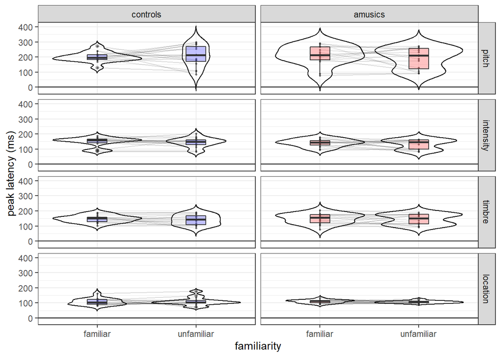

```r
flat <- ggplot(fdata,aes(condition, latency)) +
  geom_hline(yintercept = 0) +
  geom_point(alpha = 0.6,color = 'black', size = 0.6) +
  geom_line(aes(group = subject), alpha = 0.15) +
  geom_boxplot(aes(fill = group),alpha = 0.3,
               color = 'black', width = 0.2) +
  geom_violin(aes(color = group),color = 'black',
              alpha = 0.2,trim = FALSE) +
  scale_fill_manual(values = c('blue','red')) +
  facet_grid(feature~group) +
  xlab('familiarity') +
  ylab('peak latency (ms)') +
  theme_bw() +
  theme(legend.position = "none"); flat
```

Make joint familiarity reports:

```r
familiarity.report <- data.frame('model' = rownames(famp.test))
familiarity.report[2:nrow(familiarity.report),'null'] <- familiarity.report[1:nrow(familiarity.report)-1,'model']

familiarity.report <- cbind(familiarity.report,round(famp.test[,c('AIC','Chisq','Pr(>Chisq)')],2),
                           round(flat.test[,c('AIC','Chisq','Pr(>Chisq)')],2))
colnames(familiarity.report) <- c('model','null','AIC','X2','p','AIC','X2','p')

write.table(familiarity.report,file="../results/familiarity.report.csv",
            sep= ",",row.names = FALSE,quote=FALSE)
kable(familiarity.report)
```

|  | model | null | AIC | X2 | p | AIC | X2 | p |
| --- | --- | --- | --- | --- | --- | --- | --- | --- |
| fm0 | fm0 | NA | 874.99 | NA | NA | 2748.63 | NA | NA |
| fm1 | fm1 | fm0 | 874.28 | 2.71 | 0.10 | 2750.12 | 0.51 | 0.48 |
| fm2 | fm2 | fm1 | 875.41 | 0.88 | 0.35 | 2751.97 | 0.15 | 0.70 |
| fm3 | fm3 | fm2 | 806.63 | 74.78 | 0.00 | 2597.67 | 160.30 | 0.00 |
| fm4 | fm4 | fm3 | 805.45 | 7.18 | 0.07 | 2603.42 | 0.25 | 0.97 |
| fm5 | fm5 | fm4 | 806.99 | 0.46 | 0.50 | 2604.34 | 1.08 | 0.30 |
| fm6 | fm6 | fm5 | 808.77 | 4.23 | 0.24 | 2609.31 | 1.03 | 0.79 |
| fm7 | fm7 | fm6 | 811.28 | 3.49 | 0.32 | 2613.97 | 1.34 | 0.72 |

```r
familiarity.pw <- cbind(pairwise.famp,pairwise.flat[,c(2:ncol(pairwise.flat))])
write.table(familiarity.pw,file="../results/pairwise_familiarity.csv",
            sep=",",row.names = FALSE,quote=FALSE)
kable(familiarity.pw)
```

| contrast | estimate | CI 2.5% | CI 97.5% | t | p | d | estimate | CI 2.5% | CI 97.5% | t | p | d |
| --- | --- | --- | --- | --- | --- | --- | --- | --- | --- | --- | --- | --- |
| pitch - intensity | 0.86 | 0.39 | 1.32 | 4.91 | 0 | 0.61 | 62.58 | 45.40 | 79.76 | 9.70 | 0 | 1.62 |
| pitch - timbre | 0.63 | 0.17 | 1.10 | 3.61 | 0 | 0.45 | 58.81 | 41.63 | 75.99 | 9.12 | 0 | 1.52 |
| pitch - location | 1.63 | 1.16 | 2.10 | 9.32 | 0 | 1.15 | 95.39 | 78.21 | 112.57 | 14.78 | 0 | 2.46 |
| intensity - timbre | -0.23 | -0.69 | 0.24 | -1.30 | 1 | -0.16 | -3.77 | -20.95 | 13.41 | -0.58 | 1 | -0.10 |
| intensity - location | 0.77 | 0.31 | 1.24 | 4.41 | 0 | 0.55 | 32.81 | 15.63 | 49.99 | 5.09 | 0 | 0.85 |
| timbre - location | 1.00 | 0.53 | 1.46 | 5.70 | 0 | 0.71 | 36.58 | 19.40 | 53.76 | 5.67 | 0 | 0.94 |

And make a joint figure:

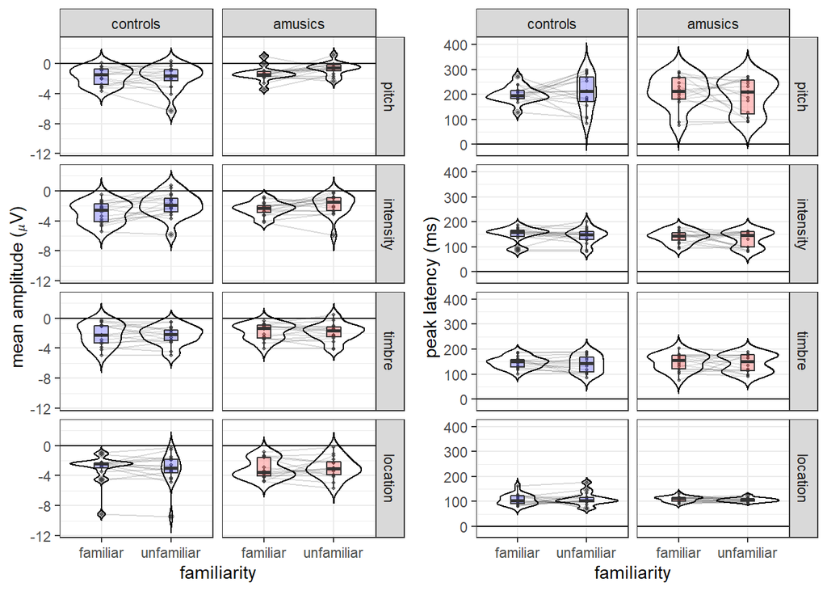

```r
fplots <- arrangeGrob(famp,flat,ncol=2);plot(fplots)
```

```r
ggsave("../results/MA_familiarity.pdf", plot=fplots,width = 170, height = 150, units = 'mm', dpi = 300)
ggsave("../results/MA_familiarity.png", plot=fplots,width = 170, height = 150, units = 'mm', dpi = 300)
```

Finally, let’s do some exploratory correlation analyses of MBEA and MMN amplitudes

```r
cors <- data.frame()
ct <- 0
for (c in unique(data$condition)){
  for (f in unique(data$feature)){
    ct = ct+1
    curd <-data[data$feature == f & data$condition == c, ]
    cor_MBEA <- cor.test(curd$MBEA,curd$amplitude)
    cor_MBEA_p <- cor.test(curd$MBEA_pitch,curd$amplitude)
    cors[ct,'condition'] <- c
    cors[ct,'feature'] <- f
    cors[ct,'r(MBEA)'] <- cor_MBEA$estimate
    cors[ct,'p(MBEA)'] <- cor_MBEA$p.value
    cors[ct,'r(MBEA.pitch)'] <- cor_MBEA_p$estimate
    cors[ct,'p(MBEA.pitch)'] <- cor_MBEA_p$p.value
  }
}
cors[,3:6] <- round(cors[,3:6],2)
kable(cors)
```

[output not shown]

```r
corsl <- data.frame()
ct <- 0
for (c in unique(data$condition)){
  for (f in unique(data$feature)){
    ct = ct+1
    curd <-data[data$feature == f & data$condition == c, ]
    cor_MBEA <- cor.test(curd$MBEA,curd$latency)
    cor_MBEA_p <- cor.test(curd$MBEA_pitch,curd$latency)
    corsl[ct,'condition'] <- c
    corsl[ct,'feature'] <- f
    corsl[ct,'r(MBEA)'] <- cor_MBEA$estimate
    corsl[ct,'p(MBEA)'] <- cor_MBEA$p.value
    corsl[ct,'r(MBEA.pitch)'] <- cor_MBEA_p$estimate
    corsl[ct,'p(MBEA.pitch)'] <- cor_MBEA_p$p.value
  }
}
corsl[,3:6] <- round(corsl[,3:6],2)
kable(corsl)
```

| condition | feature | r(MBEA) | p(MBEA) | r(MBEA.pitch) | p(MBEA.pitch) |
| --- | --- | --- | --- | --- | --- |
| LC | pitch | -0.22 | 0.22 | -0.21 | 0.23 |
| LC | intensity | -0.15 | 0.39 | -0.17 | 0.35 |
| LC | timbre | -0.01 | 0.93 | -0.05 | 0.79 |
| LC | location | 0.03 | 0.87 | 0.06 | 0.72 |
| IC | pitch | -0.17 | 0.34 | -0.29 | 0.10 |
| IC | intensity | 0.20 | 0.27 | 0.12 | 0.48 |
| IC | timbre | 0.02 | 0.90 | 0.00 | 1.00 |
| IC | location | -0.17 | 0.33 | -0.07 | 0.71 |
| HC | pitch | -0.22 | 0.22 | -0.15 | 0.39 |
| HC | intensity | 0.05 | 0.79 | 0.08 | 0.67 |
| HC | timbre | 0.03 | 0.86 | -0.04 | 0.82 |
| HC | location | -0.11 | 0.55 | -0.11 | 0.55 |
| familiar | pitch | -0.14 | 0.45 | -0.13 | 0.48 |
| familiar | intensity | 0.06 | 0.74 | 0.14 | 0.45 |
| familiar | timbre | -0.03 | 0.86 | -0.05 | 0.77 |
| familiar | location | -0.09 | 0.64 | 0.01 | 0.98 |
| unfamiliar | pitch | -0.08 | 0.66 | -0.02 | 0.91 |
| unfamiliar | intensity | 0.12 | 0.53 | 0.21 | 0.25 |
| unfamiliar | timbre | -0.11 | 0.55 | -0.09 | 0.63 |
| unfamiliar | location | 0.00 | 0.98 | 0.05 | 0.79 |